# RNA-seq : Identifying Differentially Expressed Genes

Manpreet S. Katari

#The Dataset Our goal for this experiment is to determine which *Arabidopsis thaliana* genes respond to nitrate. The dataset is a simple experiment where RNA is extracted from roots of independent plants and then sequenced. Two plants were treated with the control (KCl) and two samples were treated with Nitrate (KNO3).

Here we will attempt to perform the entire RNA-seq analysis (including alignment) using R packages.

We have been provided the following files:

1. 4 Fastq files - Original sequence files, one for each sample
2. Arabidopsis.gtf file - which contains information about the genes in Arabidopsis and where they are located in the genome.
3. Arabidopsis.fa file - the Arabidopsis genome sequence to which we will align the reads.

###Note: If one of the R packages is not loaded, you have to install it from Bioconductor

```r
install.packages("BiocManager")
BiocManager::install("Rsubread")
BiocManager::install("DESeq2")
BiocManager::install("GOstats")
BiocManager::install("GO.db")
BiocManager::install("Category")
BiocManager::install("org.At.tair.db")
```

# The RNA-seq workflow

## The Fastq files

Sequences generated from the sequencing machine are called *reads* and they are provided in a format called **fastq**. The file contains four lines per read. The first and third line contain the unique identifier for the read (most new version of fastq donât repeat the name) preceeded by an `@` and a `+` respectively. The second line contains the sequence and the fourth line contains the base quality score in ASCII format.

```r
# a quick look at the first 8 lines of the file
scan("KCL_1.fastq", what = character(), nlines=8)
```

```
## [1] "@HANNIBAL_4_FC308YYAAXX:5:1:5:738"
## [2] "ATTTAGAGGAATGAGAAGTCGTAACAAGGTTTCCGTAGGTCTTTAGGCAC"
## [3] "+HANNIBAL_4_FC308YYAAXX:5:1:5:738"
## [4] "aZaaaWZ\\U[XSJ_Z\\_]Saaaaaa^^ZKUa`XUKXXUXUGURUS[UUER"
## [5] "@HANNIBAL_4_FC308YYAAXX:5:1:5:527"
## [6] "AATGTAGGCAAGGGAAGTCGGCAAAATGGATCCGTAACTTCGGGAACTGT"
## [7] "+HANNIBAL_4_FC308YYAAXX:5:1:5:527"
## [8] "aaaaaaaaaa^X[__^X^a`_^^__`_[^_`__`X[X^`^\\UGUOXU[^["
```

Generally it is a good idea to assess the quality of the sequences and trim if necessary but newer algorithms are able to incorporate sequence and mapping quality scores to determine which are worth reporting.

## FastA file

In order to find out where in the genome the reads originate from, we have to first align them to the reference genome. The reference genome sequence is often provided in a **FastA** format. The first line of a FastA file is the name and description of the sequence preceded with a `>`. The sequence starts on the second line and is normally 60 characters per line till the end of the sequence. The format supports multiple sequences in one file where the `>` at the start of a line defines the begining of a new sequence.

We will be using the R package **Rsubread** to align the reads to the reference sequence. In order to prepare the reference sequence so we can align the reads against it, we have to first index it. We will use the **buildindex** and provide options for `basename` and `reference`. The basename will be used as the prefix to the index files the reference is the genome sequence in FastA format.

```r
library(Rsubread)

buildindex(basename="Ath_index",
           reference = "Arabidopsis.fa")
```

[output not shown]

[output cut: 19 more lines]

[output not shown]

You should now have new Ath.index.??? files in your workspace.

## The Annotation File

GTF file is very similar to a GFF file. Their purpose is to store the location of genome features, such as genes, exons, and CDS. It is a tab delimited flat file which looks something like this.

```
##   reference source feature start stop score strand phase
## 1      Chr1 TAIR10    exon  3631 3913     .      +     .
## 2      Chr1 TAIR10    exon  3996 4276     .      +     .
## 3      Chr1 TAIR10    exon  4486 4605     .      +     .
## 4      Chr1 TAIR10    exon  4706 5095     .      +     .
## 5      Chr1 TAIR10    exon  5174 5326     .      +     .
## 6      Chr1 TAIR10    exon  5439 5899     .      +     .
##                                                           annotation
## 1 transcript_id AT1G01010.1; gene_id AT1G01010; gene_name AT1G01010;
## 2 transcript_id AT1G01010.1; gene_id AT1G01010; gene_name AT1G01010;
## 3 transcript_id AT1G01010.1; gene_id AT1G01010; gene_name AT1G01010;
## 4 transcript_id AT1G01010.1; gene_id AT1G01010; gene_name AT1G01010;
## 5 transcript_id AT1G01010.1; gene_id AT1G01010; gene_name AT1G01010;
## 6 transcript_id AT1G01010.1; gene_id AT1G01010; gene_name AT1G01010;
```

## Aligning the reads

The **align()** function in Rsubread has lots of options. It is best to review the help section of the command if you have a special case for your analysis.

- The first argument is the name of the index that was used when we built the index file in the previous step.
- The second argument is a list of the fastq files.
- We are also telling the aligner that this is RNA-seq which would make it *splice aware*. We are also going to provide an annotation in *GTF* format.

```r
align("ath_index",
      c("KCL_1.fastq","KCL_2.fastq","NO3_1.fastq","NO3_2.fastq"),
      type="rna", input_format = "FASTQ",
      useAnnotation = T, annot.ext = "Arabidopsis.gtf",
      isGTF = T, phredOffset = 64)
```

[output not shown]

[output cut: 342 more lines]

```
##
## //================================   Summary =================================\\
## ||                                                                            ||
## ||                 Total reads : 5182417                                      ||
## ||                      Mapped : 4239944 (81.8%)                              ||
## ||             Uniquely mapped : 1147347                                      ||
## ||               Multi-mapping : 3092597                                      ||
## ||                                                                            ||
## ||                    Unmapped : 942473                                       ||
## ||                                                                            ||
## ||                      Indels : 7900                                         ||
## ||                                                                            ||
## ||                Running time : 11.4 minutes                                 ||
## ||                                                                            ||
## \\============================================================================//
```

```
##                       KCL_1.fastq.subread.BAM KCL_2.fastq.subread.BAM
## Total_reads                           6124001                 8324739
## Mapped_reads                          4745924                 6797552
## Uniquely_mapped_reads                 1412904                 1866317
## Multi_mapping_reads                   3333020                 4931235
## Unmapped_reads                        1378077                 1527187
## Indels                                   8348                   10459
##                       NO3_1.fastq.subread.BAM NO3_2.fastq.subread.BAM
## Total_reads                           7411916                 5182417
## Mapped_reads                          5918302                 4239944
## Uniquely_mapped_reads                 1364230                 1147347
## Multi_mapping_reads                   4554072                 3092597
## Unmapped_reads                        1493614                  942473
## Indels                                   8260                    7900
```

## The Alignment Files

The alignment files are in **bam** format. This files will not be loaded into R, but rather simply pointed to by a reference/variable. The alignment files provided are about 15x smaller compared to an average RNA-seq sample run today. Also there will be triplicates of 3 or more different conditions resulting in much more than 4 sample. So you can imagine the amount of space and memory R would need if all that data was stored in the workspace.

The **featureCounts** function will take all alignments and find out which gene is located in the region of the genome where the reads are mapping. To do this we need the BAM files and the GTF file.

```r
readcounts = featureCounts(dir(pattern = ".BAM$"),
                            annot.ext="Arabidopsis.gtf",
                            isGTFAnnotationFile=T,
                           countMultiMappingReads = F)
```

[output not shown]

[output cut: 10 more lines]

```
## ||    Single-end reads are included.                                          ||
## ||    Total alignments : 7411916                                              ||
## ||    Successfully assigned alignments : 2233024 (30.1%)                      ||
## ||    Running time : 0.36 minutes                                             ||
## ||                                                                            ||
## || Process BAM file NO3_2.fastq.subread.BAM...                                ||
## ||    Single-end reads are included.                                          ||
## ||    Total alignments : 5182417                                              ||
## ||    Successfully assigned alignments : 1900546 (36.7%)                      ||
## ||    Running time : 0.28 minutes                                             ||
## ||                                                                            ||
## || Write the final count table.                                               ||
## || Write the read assignment summary.                                         ||
## ||                                                                            ||
## \\============================================================================//
```

```r
names(readcounts)
```

```
## [1] "counts"     "annotation" "targets"    "stat"
```

```r
head(readcounts$stat)
```

```
##                      Status KCL_1.fastq.subread.BAM KCL_2.fastq.subread.BAM
## 1                  Assigned                 2204628                 3091581
## 2       Unassigned_Unmapped                 1378077                 1527187
## 3      Unassigned_Read_Type                       0                       0
## 4      Unassigned_Singleton                       0                       0
## 5 Unassigned_MappingQuality                       0                       0
## 6        Unassigned_Chimera                       0                       0
##   NO3_1.fastq.subread.BAM NO3_2.fastq.subread.BAM
## 1                 2233024                 1900546
## 2                 1493614                  942473
## 3                       0                       0
## 4                       0                       0
## 5                       0                       0
## 6                       0                       0
```

```r
head(readcounts$counts)
```

```
##           KCL_1.fastq.subread.BAM KCL_2.fastq.subread.BAM
## AT1G01010                      47                      49
## AT1G01020                       7                       6
## AT1G01030                       2                       1
## AT1G01040                      65                      66
## AT1G01046                       1                       0
## AT1G01050                      29                      31
##           NO3_1.fastq.subread.BAM NO3_2.fastq.subread.BAM
## AT1G01010                      16                      23
## AT1G01020                       4                       3
## AT1G01030                       2                       0
## AT1G01040                      64                      46
## AT1G01046                       0                       0
## AT1G01050                      35                      25
```

```r
head(readcounts$annotation)
```

```
##      GeneID
## 1 AT1G01010
## 2 AT1G01020
## 3 AT1G01030
## 4 AT1G01040
## 5 AT1G01046
## 6 AT1G01050
##                                                                                                                                                                                                       Chr
## 1                                                                                                                                                                           Chr1;Chr1;Chr1;Chr1;Chr1;Chr1
## 2                                                                                                               Chr1;Chr1;Chr1;Chr1;Chr1;Chr1;Chr1;Chr1;Chr1;Chr1;Chr1;Chr1;Chr1;Chr1;Chr1;Chr1;Chr1;Chr1
## 3                                                                                                                                                                                               Chr1;Chr1
## 4 Chr1;Chr1;Chr1;Chr1;Chr1;Chr1;Chr1;Chr1;Chr1;Chr1;Chr1;Chr1;Chr1;Chr1;Chr1;Chr1;Chr1;Chr1;Chr1;Chr1;Chr1;Chr1;Chr1;Chr1;Chr1;Chr1;Chr1;Chr1;Chr1;Chr1;Chr1;Chr1;Chr1;Chr1;Chr1;Chr1;Chr1;Chr1;Chr1;Chr1
## 5                                                                                                                                                                                                    Chr1
## 6                                                                                                                                                            Chr1;Chr1;Chr1;Chr1;Chr1;Chr1;Chr1;Chr1;Chr1
##                                                                                                                                                                                                                                             Start
```

[output cut: 27 more lines]

```r
head(readcounts$targets)
```

```
## [1] "KCL_1.fastq.subread.BAM" "KCL_2.fastq.subread.BAM"
## [3] "NO3_1.fastq.subread.BAM" "NO3_2.fastq.subread.BAM"
```

## The Experimental Design

We will create a factor to define which columns have which sample.

```r
expdesign = factor(c("KCL","KCL","NO3","NO3"))
```

## Counting the Reads

The actual gene counts are saved in the `counts` element in `readcounts`

```r
counts = readcounts$counts
```

## Filtering the Counts

Now, if you remember from the lecture, genes that are expressed at a very low level are extremely unreliable. We will remove all genes if neither of the groups ( KCL or KNO3 ) have a median count of 10 and call the new dataframe **counts_filtered**.

```r
medianCountByGroup = t(apply(counts, 1, tapply,
                             expdesign, median))

maxMedian=apply(medianCountByGroup, 1, max)

counts_filtered = counts[maxMedian>=10,]
```

## Differentially Expressed Genes

Now that we have the counts table filtered, we can start to determine if any of the genes are significantly differentially expressed using *DESeq2*.

```r
library(DESeq2)
cds = DESeqDataSetFromMatrix(countData=counts_filtered,
                             colData=data.frame(condition=expdesign),
                             design= ~ condition)
```

Before the actual test, DESeq has to consider the difference in total reads from the different samples. This is done by using *estimateSizeFactors* function.

```r
cds = estimateSizeFactors(cds)
```

Next DESeq will estimate the dispersion ( or variation ) of the data. If there are no replicates, DESeq can manage to create a theoretical dispersion but this is not ideal.

```r
cds = estimateDispersions( cds )
```

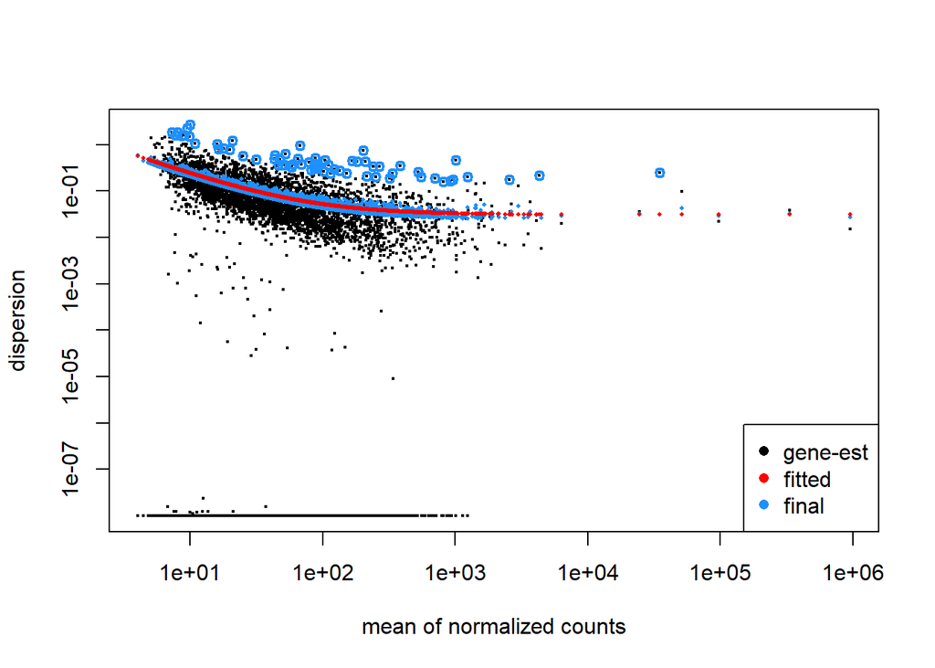

```r
plotDispEsts( cds )
```

The plot shows us that as the geneâs read count increases, dispersion decreases, which is what we expect. Now we will tell DESeq what we would like to compare. Then we will use the adjusted p-value ( p-value corrected for multiple hypothesis testing ) for our cutoff.

```r
cds <- DESeq(cds)
```

```
## found already estimated dispersions, replacing these
```

```r
res <- results(cds)
head(res)
```

```
## log2 fold change (MLE): condition NO3 vs KCL
## Wald test p-value: condition NO3 vs KCL
## DataFrame with 6 rows and 6 columns
##            baseMean log2FoldChange     lfcSE      stat    pvalue      padj
##           <numeric>      <numeric> <numeric> <numeric> <numeric> <numeric>
## AT1G01010   31.4046      -0.607849  0.514018 -1.182545 0.2369896  0.999997
## AT1G01040   59.7605       0.401103  0.389880  1.028787 0.3035799  0.999997
## AT1G01050   30.3043       0.656600  0.496587  1.322225 0.1860931  0.999997
## AT1G01060   85.5597      -0.266226  0.372656 -0.714402 0.4749789  0.999997
## AT1G01090  130.1269       0.277322  0.309434  0.896223 0.3701339  0.999997
## AT1G01100  808.8771       0.412732  0.240210  1.718210 0.0857583  0.949334
```

```r
sum(res$padj < 0.05, na.rm=T)
```

```
## [1] 276
```

The sum command is normally used to add numberic values. However in logic vectors, TRUE=1 and FALSE=0, so we can use the sum function to count the number of âTRUEâ in the vector. In the example we counted the number of genes that have a an adjusted p-value less than 0.05.

## MA Plot

Hereâs an MA plot that shows as the average count of a gene increases, a smaller fold change is needed for something to be significant. For this reason, it is often helpful to require that the log2foldchange also be greater than or less than negative of some cutoff.

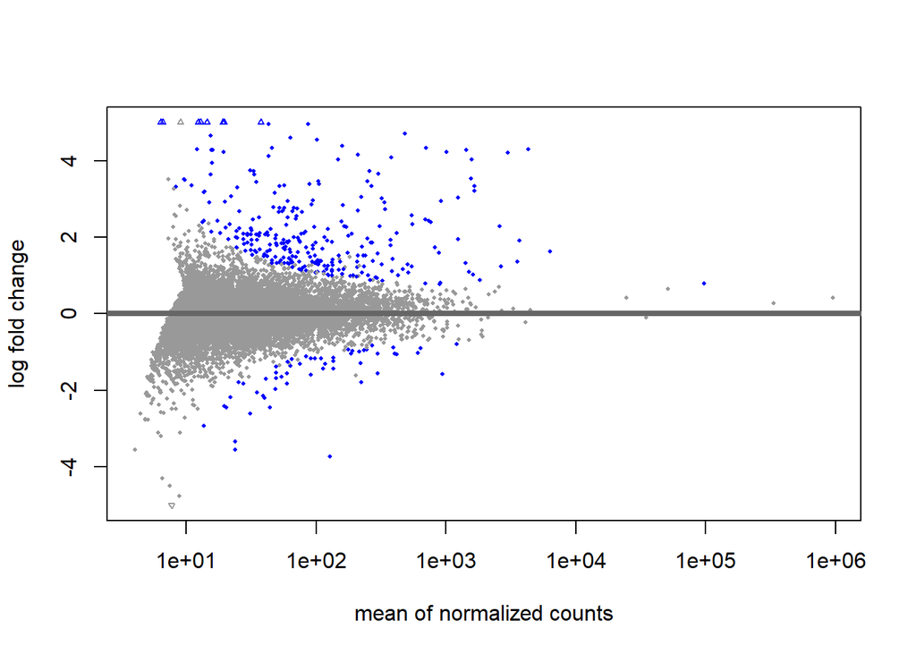

```r
plotMA(res, ylim=c(-5,5))
```

## Significant genes

```r
resSigind = res[ which(res$padj < 0.05 & res$log2FoldChange > 0), ]
resSigrep = res[ which(res$padj < 0.05 & res$log2FoldChange < 0), ]
resSig = rbind(resSigind, resSigrep)

rownames(resSigind)
```

```
##   [1] "AT1G01490" "AT1G03220" "AT1G03850" "AT1G07150" "AT1G07610" "AT1G08090"
##   [7] "AT1G08100" "AT1G08650" "AT1G09780" "AT1G11655" "AT1G12110" "AT1G12580"
##  [13] "AT1G13245" "AT1G13300" "AT1G13420" "AT1G13440" "AT1G14340" "AT1G19050"
##  [19] "AT1G21000" "AT1G22170" "AT1G22500" "AT1G22650" "AT1G23870" "AT1G24280"
##  [25] "AT1G25550" "AT1G30270" "AT1G30510" "AT1G30840" "AT1G31200" "AT1G31770"
##  [31] "AT1G32380" "AT1G32920" "AT1G35560" "AT1G37130" "AT1G43710" "AT1G45249"
##  [37] "AT1G49000" "AT1G49160" "AT1G49450" "AT1G49860" "AT1G50110" "AT1G55120"
##  [43] "AT1G59940" "AT1G59960" "AT1G59970" "AT1G60050" "AT1G60710" "AT1G61740"
##  [49] "AT1G62180" "AT1G63940" "AT1G64190" "AT1G66140" "AT1G66200" "AT1G67110"
##  [55] "AT1G67920" "AT1G68238" "AT1G68670" "AT1G68880" "AT1G70260" "AT1G70410"
##  [61] "AT1G73920" "AT1G74030" "AT1G77760" "AT1G78000" "AT1G78050" "AT1G80310"
##  [67] "AT1G80380" "AT1G80440" "AT2G01140" "AT2G15620" "AT2G16060" "AT2G17820"
##  [73] "AT2G18960" "AT2G24550" "AT2G24790" "AT2G26820" "AT2G26980" "AT2G27510"
##  [79] "AT2G28550" "AT2G28780" "AT2G28890" "AT2G30040" "AT2G30100" "AT2G30660"
##  [85] "AT2G30670" "AT2G33550" "AT2G36090" "AT2G36320" "AT2G36530" "AT2G36580"
```

[output cut: 25 more lines]

```r
rownames(resSigrep)
```

```
##  [1] "AT1G13110" "AT1G20620" "AT1G29050" "AT1G47128" "AT1G51680" "AT1G55760"
##  [7] "AT1G64590" "AT1G67810" "AT1G76350" "AT1G79320" "AT2G17710" "AT2G32560"
## [13] "AT3G01290" "AT3G01420" "AT3G03780" "AT3G03870" "AT3G09220" "AT3G09270"
## [19] "AT3G21420" "AT3G23810" "AT3G44540" "AT3G48340" "AT4G08300" "AT4G12290"
## [25] "AT4G15610" "AT4G16190" "AT4G17030" "AT4G17670" "AT4G33040" "AT4G39795"
## [31] "AT5G06510" "AT5G10770" "AT5G16570" "AT5G18130" "AT5G19140" "AT5G37600"
## [37] "AT5G40780" "AT5G45380" "AT5G64410" "AT5G66170"
```

## Gene Annotations

Before we do this, note that the identified in the gene_description file is slightly different ( the file contains the transcript identifier that ends with â.â and a number), Letâs replace every occurrence of . and a number with nothing. Then we will be able to use **match** to find where our gene is in the description file so we can only print out that row.

```r
gene_description <- read.delim("gene_description_20131231.txt",
                               header=FALSE, quote="")
genenames = gsub("[.][1234567890]", "",
                 gene_description[,1])

gene_description[,1]=genenames

gene_match_rows=match(rownames(resSig), gene_description[,1])
gene_description[gene_match_rows,c(1,3)]
```

```
##              V1
## 2290  AT1G01490
## 1281  AT1G03220
## 2096  AT1G03850
## 376   AT1G07150
## 23615 AT1G07610
## 21896 AT1G08090
## 21897 AT1G08100
## 2305  AT1G08650
## 2132  AT1G09780
## 28800 AT1G11655
## 23961 AT1G12110
## 23752 AT1G12580
## 28681 AT1G13245
## 21921 AT1G13300
```

[output cut: 539 more lines]

## GO-term enrichment analysis

Getting the gene names are informative but it is hard to determine whether a speicifc category of terms are over-represented in this analysis. So we will perform a GO-term enrichment analysis of all differentially expressed genes using a Hypergeometric test to determine if there is any GO-term that is enriched in this list.

To run the test using the GOstats package, we must first create a GOHyperGParams object as shown below. Here we will provided the genes in the list, the universe of all genes, which GOterm gene space we are interested in, a p-value cutoff, and if we want an additional conditional test. The conditional test looks at parent and child relationship of the GO-terms. If the parent term and the child term are over-represented, the parent-term has to be significantly more over-represented to show up in the list of over-represented GO-terms. This avoids the problem where many over-represented GO-terms are parent or child of another and the terms appear to be very redundant.

```r
library(GOstats)
library(GO.db)
library(Category)
library(org.At.tair.db)
params=new("GOHyperGParams",
  geneIds=rownames(resSig),
  universeGeneIds=rownames(counts_filtered),
  annotation="org.At.tair",
  ontology="BP",
  pvalueCutoff=0.001,
  conditional=TRUE,
  testDirection="over")
```

To get actually perform the test we use the hyperGTest function and to see the results simply use the summary function.

```r
(overRepresented=hyperGTest(params))
```

```
## Gene to GO BP Conditional test for over-representation
## 1083 GO BP ids tested (52 have p < 0.001)
## Selected gene set size: 233
##     Gene universe size: 10350
##     Annotation package: org.At.tair
```

```r
summary(overRepresented)[,c(1,2,5,6,7)]
```

```
##        GOBPID       Pvalue Count Size
## 1  GO:0042128 2.681825e-11     8   12
## 2  GO:0006091 1.910000e-10    24  224
## 3  GO:2001057 6.449270e-10     8   16
## 4  GO:0043436 6.789119e-10    44  716
## 5  GO:0006096 1.376829e-09    11   42
## 6  GO:0009135 1.376829e-09    11   42
## 7  GO:0046031 1.376829e-09    11   42
## 8  GO:0009185 2.370840e-09    11   44
## 9  GO:0006165 6.452049e-09    11   48
## 10 GO:0006739 3.066271e-08     9   33
## 11 GO:0010167 1.071835e-07     7   19
## 12 GO:0044281 8.105960e-07    49 1068
## 13 GO:0009051 1.273274e-06     5   10
## 14 GO:0010035 1.277443e-06    36  702
```

[output cut: 91 more lines]

## Do the results make sense?

The experiment that was performed was to see how plants respond to the presence of extra nitrogen provided in the soil. Two groups of plants were analyzed, KCL (control potassium chloride) and NO3 (the treatment Nitrate). We sequenced the RNA of two groups of plants and mapped them back the region where the sequences were coming from.

We then identified genes that are differentially expressed and performed a GO-term analysis to see which biological process are over-represented. It makes sense that some over-representd categories in the list of genes is âresponse to nitrateâ and ânitrate transportâ